# Under Armour Technical Appendix"

Qi Ming Wei

June 14, 2019

## 0.1 Question , Dataset, Variables

- My question is to find out if apparel consumption is driven by materialistic of hedonistic values, and how these values apply to the future purchase possibility of the product

## 0.2 Data

- my dataset is underarmour data set

## 0.3 Variables

- my variables will be categories of brand attitudes, UAIntent,environmental(for fills), knowledge1, materialism, physfit, prodaest, prodvalue, prodpur, online or retail

```r
# Clear environment of variables and functions
rm(list = ls(all = TRUE))

# Clear environmet of packages
if(is.null(sessionInfo()$otherPkgs) == FALSE)lapply(paste("package:", names(sessionInfo()$otherPkgs), sep=""), detach, character.only = TRUE, unload = TRUE)
```

```r
# Install Packages

library(tidyverse)
library(GGally)
library(gridExtra)
library(corrplot)
```

### 0.3.1 Base EDA

```r
# Load data
U_A<-read.csv("Under_Armour.csv")

# Review data
summary(U_A)
```

```
##                brandatt1                brandatt2
##  moderately agree   :64   moderately agree   :66
##  strongly agree     :62   strongly agree     :54
##  neutral            :54   neutral            :51
##  slightly agree     :40   slightly agree     :44
##  moderately disagree: 4   moderately disagree:10
##  (Other)            : 4   (Other)            : 3
##  NA's               : 2   NA's               : 2
##                brandatt3                  Cause1
##  neutral            :63   strongly agree     :74
##  moderately agree   :57   moderately agree   :50
##  strongly agree     :55   slightly agree     :46
##  slightly agree     :36   neutral            :41
##  moderately disagree:10   moderately disagree: 7
##  (Other)            : 6   (Other)            : 8
##  NA's               : 3   NA's               : 4
##                  Cause2                   Cause3
##  moderately agree   :53   moderately agree   : 51
##  moderately disagree:11   moderately disagree:  5
##  neutral            :53   neutral            : 12
##  slightly agree     :48   slightly agree     : 49
##  slightly disagree  : 7   slightly disagree  :  3
##  strongly agree     :49   strongly agree     :106
##  strongly disagree  : 9   strongly disagree  :  4
##                 compan1                 compan2
##  strongly agree     :107   strongly agree   :79
##  moderately agree   : 73   moderately agree :73
##  slightly agree     : 19   slightly agree   :40
##  neutral            : 18   neutral          :25
##  moderately disagree:  6   slightly disagree: 6
##  (Other)            :  5   (Other)          : 6
##  NA's               :  2   NA's             : 1
##                 compan3                     CSR1
##  moderately agree   : 27   moderately agree   : 67
##  moderately disagree:  2   moderately disagree:  5
##  neutral            :  5   neutral            : 14
##  slightly agree     : 12   slightly agree     : 33
##  strongly agree     :174   slightly disagree  :  2
##  strongly disagree  :  6   strongly agree     :107
##  NA's               :  4   strongly disagree  :  2
```

[output cut: 193 more lines]

```
##  slight positive influence  :88   Min.   :18.00
##  no influence               :70   1st Qu.:20.00
##  moderate positive influence:40   Median :24.50
##  strong positive influence  :18   Mean   :26.63
##  slight negative influence  : 8   3rd Qu.:33.00
##  (Other)                    : 4   Max.   :55.00
##  NA's                       : 2
##                   income
##  below 20,000        :45
##  40,000-59,999       :28
##  80,000-99,999       :27
##  prefer not to answer:25
##  60,000-79,999       :24
##  (Other)             :51
##  NA's                :30
```

```r
str(U_A)
```

```
## 'data.frame':    230 obs. of  77 variables:
##  $ brandatt1   : Factor w/ 7 levels "moderately agree",..: 1 4 1 4 1 6 1 1 3 3 ...
##  $ brandatt2   : Factor w/ 7 levels "moderately agree",..: 4 4 6 4 1 6 4 1 3 3 ...
##  $ brandatt3   : Factor w/ 7 levels "moderately agree",..: 1 4 1 4 4 6 3 1 4 3 ...
##  $ Cause1      : Factor w/ 7 levels "moderately agree",..: 1 6 1 1 2 6 1 4 1 1 ...
##  $ Cause2      : Factor w/ 7 levels "moderately agree",..: 1 4 4 1 4 6 5 4 3 3 ...
##  $ Cause3      : Factor w/ 7 levels "moderately agree",..: 6 6 6 6 2 6 6 4 1 4 ...
##  $ compan1     : Factor w/ 7 levels "moderately agree",..: 6 1 1 1 3 6 6 4 1 1 ...
##  $ compan2     : Factor w/ 7 levels "moderately agree",..: 1 4 1 1 4 6 6 4 1 1 ...
##  $ compan3     : Factor w/ 6 levels "moderately agree",..: 5 5 5 5 1 5 5 4 5 5 ...
##  $ CSR1        : Factor w/ 7 levels "moderately agree",..: 6 1 1 6 3 6 6 4 4 6 ...
##  $ CSR2        : Factor w/ 7 levels "moderately agree",..: 3 1 1 6 NA 6 1 3 4 4 ...
##  $ CSR3        : Factor w/ 7 levels "moderately agree",..: 3 3 1 6 1 6 6 4 1 4 ...
##  $ environ1    : Factor w/ 7 levels "moderately agree",..: 6 4 1 6 6 6 6 4 4 5 ...
##  $ environ2    : Factor w/ 6 levels "moderately agree",..: 5 NA 4 5 1 5 5 4 1 3 ...
```

[output cut: 63 more lines]

# 1 comments

- there is too much variables and out comes to look at with just like this
- in terms of future purchases, most of the surveys are neutral standing.
- most surveys are not feminime related
- it is necessary to compute correlation graph and determine from there

```r
# Change the scale of survey to numeric
U_A <-U_A %>%
  mutate_all(funs(str_replace(., "strongly agree", "3"))) %>%
  mutate_all(funs(str_replace(., "moderately agree", "2"))) %>%
  mutate_all(funs(str_replace(., "slightly agree", "1"))) %>%
  mutate_all(funs(str_replace(., "neutral", "0"))) %>%
  mutate_all(funs(str_replace(., "slightly disagree", "-1"))) %>%
  mutate_all(funs(str_replace(., "moderately disagree", "-2"))) %>%
  mutate_all(funs(str_replace(., "strongly disagree", "-3"))) %>%

#Change influence to numeric levels
  mutate_all(funs(str_replace(., "strong positive influence", "3"))) %>%
  mutate_all(funs(str_replace(., "moderate positive influence", "2")))%>%
  mutate_all(funs(str_replace(., "slight positive influence", "1")))%>%
  mutate_all(funs(str_replace(., "no influence", "0")))%>%
  mutate_all(funs(str_replace(., "slight negative influence", "-1"))) %>%
  mutate_all(funs(str_replace(., "moderate negative influence", "-2")))%>%
  mutate_all(funs(str_replace(., "strong negative influence", "-3")))%>%

#change income ffrom 0 to 8
  mutate_all(funs(str_replace(., "below 20,000", "1"))) %>%
  mutate_all(funs(str_replace(., "20,000-39,999", "2"))) %>%
  mutate_all(funs(str_replace(., "40,000-59,999", "3"))) %>%
  mutate_all(funs(str_replace(., "60,000-79,999", "4"))) %>%
  mutate_all(funs(str_replace(., "80,000-99,999", "5"))) %>%
  mutate_all(funs(str_replace(., "100,000-149,999", "6"))) %>%
  mutate_all(funs(str_replace(., "150,000-199,999", "7"))) %>%
  mutate_all(funs(str_replace(., "200,000 or above", "8"))) %>%
  mutate_all(funs(str_replace(., "prefer not to answer", "0"))) %>%

# Change Yes to 1 no to 0
  mutate_all(funs(str_replace(., "yes", "1"))) %>%
  mutate_all(funs(str_replace(., "no", "0")))%>%
  mutate_all(funs(as.numeric(.)))
head(U_A)
```

```
##   brandatt1 brandatt2 brandatt3 Cause1 Cause2 Cause3 compan1 compan2
## 1         2         1         2      2      2      3       3       2
## 2         1         1         1      3      1      3       2       1
## 3         2         3         2      2      1      3       2       2
## 4         1         1         1      2      2      3       2       2
## 5         2         2         1     -2      1     -2       0       1
## 6         3         3         3      3      3      3       3       3
##   compan3 CSR1 CSR2 CSR3 environ1 environ2 environ3 knowledge1 knowledge2
## 1       3    3    0    0        3        3        3          1          2
## 2       3    2    2    0        1       NA        1          2          2
## 3       3    2    2    2        2        1        2          3          1
## 4       3    3    3    3        3        3        3          3          1
## 5       2    0   NA    2        3        2        2          0          2
## 6       3    3    3    3        3        3        3          3          3
##   knowledge3 materialism1 materialism2 materialism3 physfit1 physfit2
```

[output cut: 55 more lines]

```r
str(U_A)
```

```
## 'data.frame':    230 obs. of  77 variables:
##  $ brandatt1   : num  2 1 2 1 2 3 2 2 0 0 ...
##  $ brandatt2   : num  1 1 3 1 2 3 1 2 0 0 ...
##  $ brandatt3   : num  2 1 2 1 1 3 0 2 1 0 ...
##  $ Cause1      : num  2 3 2 2 -2 3 2 1 2 2 ...
##  $ Cause2      : num  2 1 1 2 1 3 -1 1 0 0 ...
##  $ Cause3      : num  3 3 3 3 -2 3 3 1 2 1 ...
##  $ compan1     : num  3 2 2 2 0 3 3 1 2 2 ...
##  $ compan2     : num  2 1 2 2 1 3 3 1 2 2 ...
##  $ compan3     : num  3 3 3 3 2 3 3 1 3 3 ...
##  $ CSR1        : num  3 2 2 3 0 3 3 1 1 3 ...
##  $ CSR2        : num  0 2 2 3 NA 3 2 0 1 1 ...
##  $ CSR3        : num  0 0 2 3 2 3 3 1 2 1 ...
##  $ environ1    : num  3 1 2 3 3 3 3 1 1 -1 ...
##  $ environ2    : num  3 NA 1 3 2 3 3 1 2 0 ...
```

[output cut: 63 more lines]

# 2 new variables to represent the categories

```r
U_A.num <- U_A %>%
  mutate(brandatt = rowMeans(select(., contains('brandatt')), na.rm = TRUE))%>%
  mutate(materialism = rowMeans(select(., contains('materialism')), na.rm = TRUE))%>%
  mutate(physfit = rowMeans(select(., contains('physfit')), na.rm = TRUE))%>%
  mutate(prodaest = rowMeans(select(., contains('Prodaest')), na.rm = TRUE))%>%
  mutate(prodvalue = rowMeans(select(., contains('Prodvalue')), na.rm = TRUE))%>%
  mutate(prodpur = rowMeans(select(., contains('prodpur')), na.rm = TRUE))%>%
  mutate(UAIntent = rowMeans(select(., contains('UAIntent')), na.rm = TRUE))%>%
  mutate(environment = rowMeans(select(., contains('environ')), na.rm = TRUE))%>%
  mutate(prodqual = rowMeans(select(., contains('prodqual')), na.rm = TRUE))%>%
  mutate_if(is.numeric, round, 0)
```

```r
mydata <- U_A.num %>% select(c("brandatt", "physfit","environment", "knowledge1", "prodaest", "prodvalue", "prodpur", "UAIntent", "prodqual", 'materialism'))


U_A.factor <- mydata %>% mutate_if(is.numeric, round, 0) %>%
  mutate_all(funs(as.factor(.)))

U_A.Comb <- bind_cols(U_A, U_A.factor)

head(U_A.factor)
```

```
##   brandatt physfit environment knowledge1 prodaest prodvalue prodpur
## 1        2       3           3          1        0         0       2
## 2        1       2           1          2        2         2       2
## 3        2       3           2          3        2         2       3
## 4        1       2           3          3        0         2       3
## 5        2       2           2          0        2        -1       2
## 6        3       3           3          3        2         2       3
##   UAIntent prodqual materialism
## 1        1        2          -2
## 2        2        3           1
## 3        3        2           1
## 4        1        3           0
## 5        0        2          -1
## 6        3        3          -2
```

# 3 Mini correlations

```r
UA_1 <- U_A[,c("brandatt1", "brandatt2", "brandatt3", "UAIntent1", "UAIntent2", "UAIntent3")]%>%
  as.data.frame()


# Standard correlation table
cor(UA_1, use="pairwise.complete.obs") %>%
  round(2)
```

```
##           brandatt1 brandatt2 brandatt3 UAIntent1 UAIntent2 UAIntent3
## brandatt1      1.00      0.85      0.81      0.74      0.71      0.74
## brandatt2      0.85      1.00      0.82      0.74      0.75      0.79
## brandatt3      0.81      0.82      1.00      0.82      0.85      0.86
## UAIntent1      0.74      0.74      0.82      1.00      0.90      0.90
## UAIntent2      0.71      0.75      0.85      0.90      1.00      0.91
## UAIntent3      0.74      0.79      0.86      0.90      0.91      1.00
```

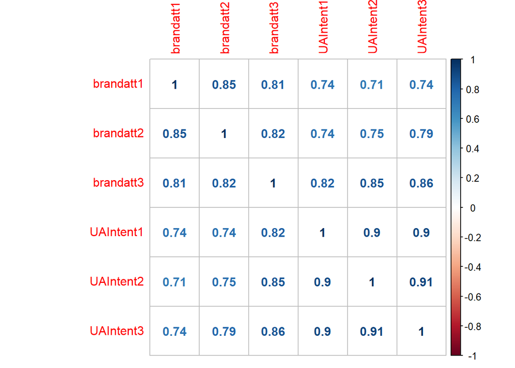

```r
# correlation graph
cor(UA_1, use="pairwise.complete.obs")%>%
  corrplot(method = "number")
```

#comments

- in terms of future purchase, according to the corrleation graph, liking the brand “under armor” leads to the highest chance of future purchases.
- all three varaibles has a relative high correlation with future purchases

```r
UA_2 <- U_A[,c("CSR1", "CSR2", "CSR3", "UAIntent1", "UAIntent2", "UAIntent3")]%>%
  as.data.frame()


# Standard correlation table
cor(UA_2, use="pairwise.complete.obs") %>%
  round(2)
```

```
##           CSR1 CSR2 CSR3 UAIntent1 UAIntent2 UAIntent3
## CSR1      1.00 0.67 0.68      0.38      0.38      0.39
## CSR2      0.67 1.00 0.71      0.31      0.31      0.29
## CSR3      0.68 0.71 1.00      0.24      0.24      0.24
## UAIntent1 0.38 0.31 0.24      1.00      0.90      0.90
## UAIntent2 0.38 0.31 0.24      0.90      1.00      0.91
## UAIntent3 0.39 0.29 0.24      0.90      0.91      1.00
```

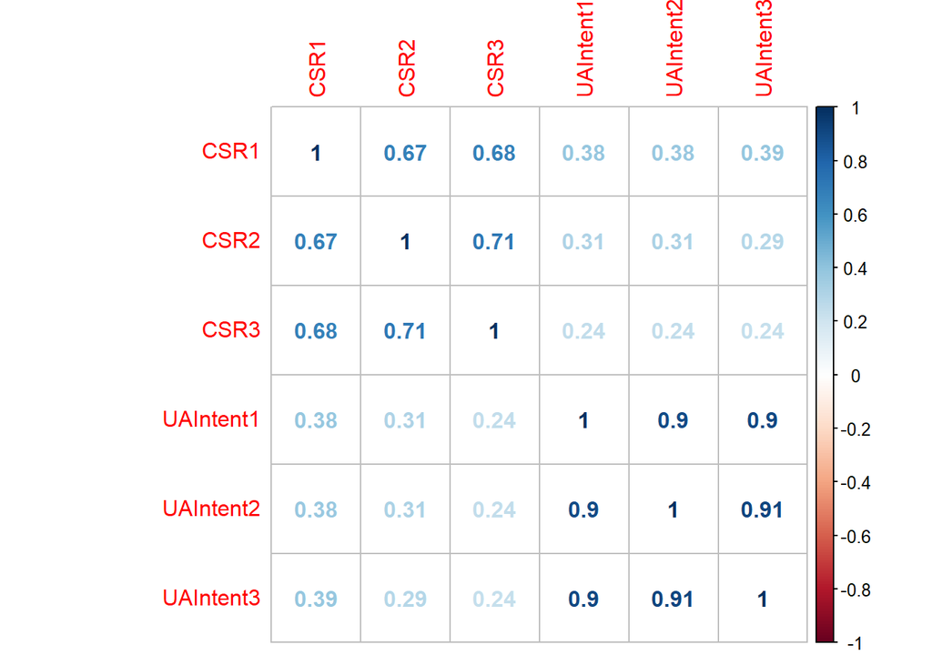

```r
# correlation graph
cor(UA_2, use="pairwise.complete.obs")%>%
  corrplot(method = "number")
```

# 4 comments

- none of these variables have alot of correlation with future purchases

```r
UA_3 <- U_A[,c("knowledge1", "knowledge2", "knowledge3", "UAIntent1", "UAIntent2", "UAIntent3")]%>%
  as.data.frame()


# Standard correlation table
cor(UA_3, use="pairwise.complete.obs") %>%
  round(2)
```

```
##            knowledge1 knowledge2 knowledge3 UAIntent1 UAIntent2 UAIntent3
## knowledge1       1.00       0.66       0.67      0.62      0.59      0.59
## knowledge2       0.66       1.00       0.73      0.48      0.45      0.46
## knowledge3       0.67       0.73       1.00      0.51      0.48      0.53
## UAIntent1        0.62       0.48       0.51      1.00      0.90      0.90
## UAIntent2        0.59       0.45       0.48      0.90      1.00      0.91
## UAIntent3        0.59       0.46       0.53      0.90      0.91      1.00
```

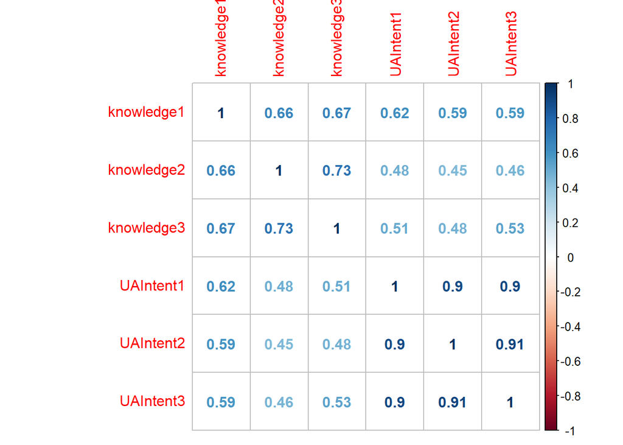

```r
# correlation graph
cor(UA_3, use="pairwise.complete.obs")%>%
  corrplot(method = "number")
```

# Comment - knownledge 1 has a relative high correlation with future purchases

```r
UA_4 <- U_A[,c("physfit1", "physfit2", "physfit3","materialism1","materialism2", "materialism3", "Prodaest1", "Prodaest2", "Prodaest3", "Prodaest4")]%>%
  as.data.frame()


# Standard correlation table
cor(UA_4, use="pairwise.complete.obs") %>%
  round(2)
```

```
##              physfit1 physfit2 physfit3 materialism1 materialism2
## physfit1         1.00     0.88     0.82         0.07         0.02
## physfit2         0.88     1.00     0.83         0.01        -0.02
## physfit3         0.82     0.83     1.00         0.06         0.05
## materialism1     0.07     0.01     0.06         1.00         0.68
## materialism2     0.02    -0.02     0.05         0.68         1.00
## materialism3     0.25     0.24     0.29         0.56         0.59
## Prodaest1        0.47     0.49     0.47         0.41         0.28
## Prodaest2        0.43     0.45     0.47         0.24         0.28
## Prodaest3        0.57     0.56     0.59         0.25         0.26
## Prodaest4        0.58     0.61     0.61         0.27         0.26
##              materialism3 Prodaest1 Prodaest2 Prodaest3 Prodaest4
## physfit1             0.25      0.47      0.43      0.57      0.58
## physfit2             0.24      0.49      0.45      0.56      0.61
## physfit3             0.29      0.47      0.47      0.59      0.61
## materialism1         0.56      0.41      0.24      0.25      0.27
## materialism2         0.59      0.28      0.28      0.26      0.26
## materialism3         1.00      0.38      0.38      0.37      0.44
## Prodaest1            0.38      1.00      0.50      0.66      0.65
## Prodaest2            0.38      0.50      1.00      0.64      0.69
## Prodaest3            0.37      0.66      0.64      1.00      0.72
## Prodaest4            0.44      0.65      0.69      0.72      1.00
```

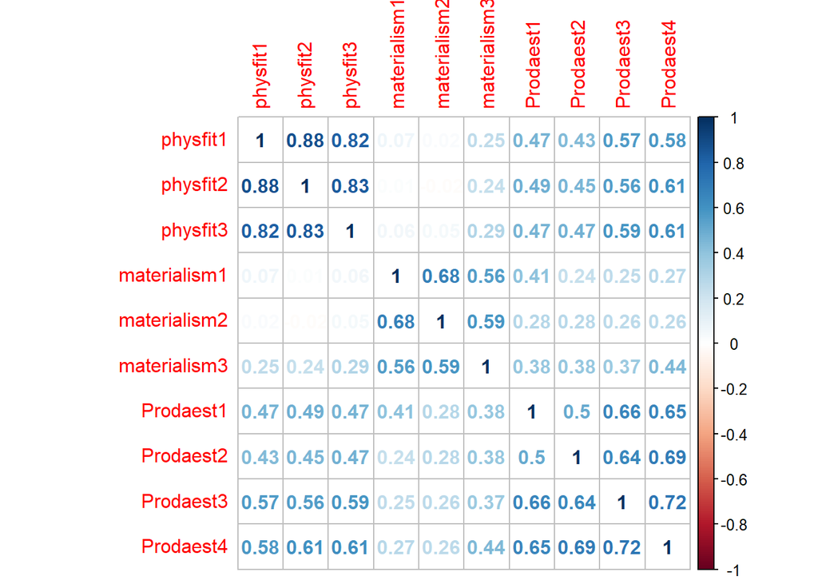

```r
# correlation graph
cor(UA_4, use="pairwise.complete.obs")%>%
  corrplot(method = "number")
```

#comments - over all physfit varibles has a higher correlation to Prodaest variables than materialism

```r
UA_5 <- U_A[,c("prodpur1", "prodpur2", "prodpur3", "UAIntent1", "UAIntent2", "UAIntent3")]%>%
  as.data.frame()


# Standard correlation table
cor(UA_5, use="pairwise.complete.obs") %>%
  round(2)
```

```
##           prodpur1 prodpur2 prodpur3 UAIntent1 UAIntent2 UAIntent3
## prodpur1      1.00     0.90     0.85      0.58      0.52      0.57
## prodpur2      0.90     1.00     0.86      0.58      0.51      0.55
## prodpur3      0.85     0.86     1.00      0.54      0.51      0.56
## UAIntent1     0.58     0.58     0.54      1.00      0.90      0.90
## UAIntent2     0.52     0.51     0.51      0.90      1.00      0.91
## UAIntent3     0.57     0.55     0.56      0.90      0.91      1.00
```

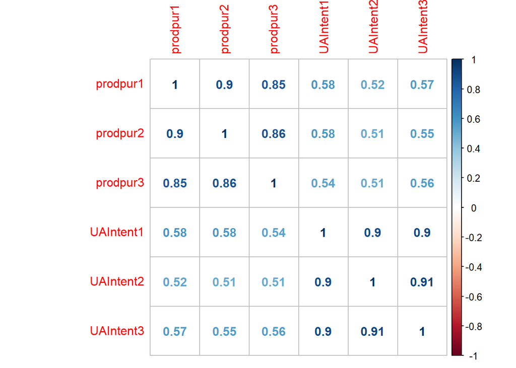

```r
# correlation graph
cor(UA_5, use="pairwise.complete.obs")%>%
  corrplot(method = "number")
```

- above 50% of female customers consider UA to be a sports performance brand - there is a above 50% corelation between Produp 1

```r
UA_6 <- U_A[,c("physfit1", "physfit2", "physfit3", "Prodaest2", "Prodaest3", "Prodaest4", "UAIntent1","UAIntent2","UAIntent3")]%>%
  as.data.frame()


# Standard correlation table
cor(UA_6, use="pairwise.complete.obs") %>%
  round(2)
```

```
##           physfit1 physfit2 physfit3 Prodaest2 Prodaest3 Prodaest4
## physfit1      1.00     0.88     0.82      0.43      0.57      0.58
## physfit2      0.88     1.00     0.83      0.45      0.56      0.61
## physfit3      0.82     0.83     1.00      0.47      0.59      0.61
## Prodaest2     0.43     0.45     0.47      1.00      0.64      0.69
## Prodaest3     0.57     0.56     0.59      0.64      1.00      0.72
## Prodaest4     0.58     0.61     0.61      0.69      0.72      1.00
## UAIntent1     0.35     0.33     0.32      0.44      0.54      0.43
## UAIntent2     0.31     0.33     0.30      0.38      0.52      0.43
## UAIntent3     0.37     0.36     0.34      0.41      0.52      0.46
##           UAIntent1 UAIntent2 UAIntent3
## physfit1       0.35      0.31      0.37
## physfit2       0.33      0.33      0.36
## physfit3       0.32      0.30      0.34
## Prodaest2      0.44      0.38      0.41
## Prodaest3      0.54      0.52      0.52
## Prodaest4      0.43      0.43      0.46
## UAIntent1      1.00      0.90      0.90
## UAIntent2      0.90      1.00      0.91
## UAIntent3      0.90      0.91      1.00
```

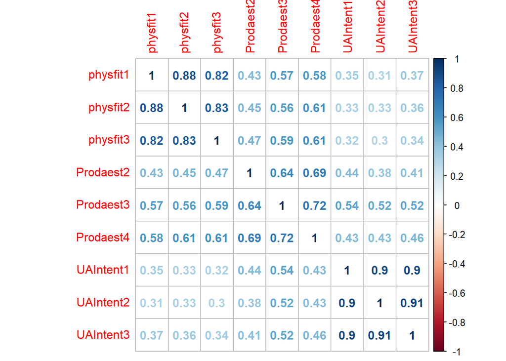

```r
# correlation graph
cor(UA_6, use="pairwise.complete.obs")%>%
  corrplot(method = "number")
```

## 4.1 Univeriate Graphical- Qualitative EDA

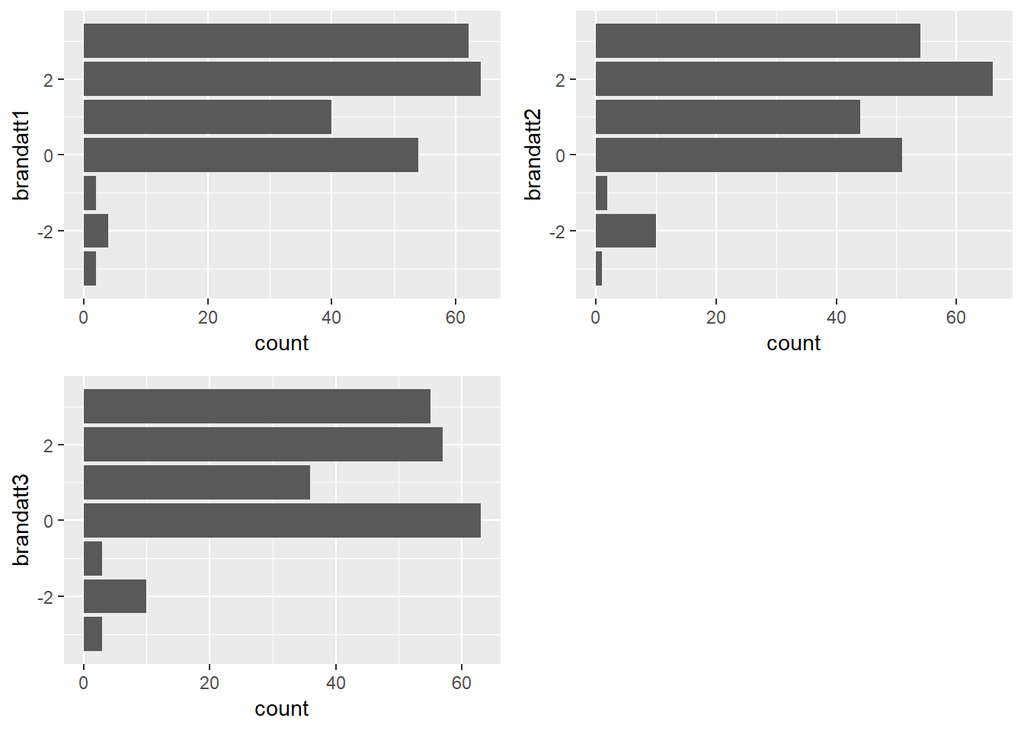

```r
# The repuration of Under Armour from survey

grid.arrange(
  U_A %>%
    ggplot(aes(brandatt1)) +
    geom_bar() +
    coord_flip(),
  U_A %>%
    ggplot(aes(brandatt2)) +
    geom_bar() +
    coord_flip(),
  U_A %>%
    ggplot(aes(brandatt3)) +
    geom_bar() +
    coord_flip(),
  ncol=2)
```

#comments - There are more positive brand attitude than negative brand attitude. - For brandatt3, “I like underarmor”, most people are neutrual - I know from the correlation above, brand attitude has a high positive correlation with UAIntent

# 5 Questions

- how are the brand attitude also affected by environmental awareness
- what causes a positive brand attitude

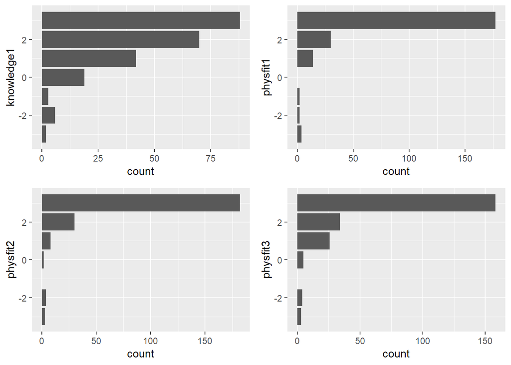

```r
# Use grid.arrange to show all the quantiry of variables showing the imapact of sales

grid.arrange(
  U_A %>%
    ggplot(aes(knowledge1)) +
    geom_bar() +
    coord_flip(),
  U_A %>%
    ggplot(aes(physfit1)) +
    geom_bar() +
    coord_flip(),
  U_A %>%
    ggplot(aes(physfit2)) +
    geom_bar() +
    coord_flip(),
  U_A %>%
    ggplot(aes(physfit3)) +
    geom_bar() +
    coord_flip(),
  ncol=2)
```

#comments - Most of the female consumers do have knowledge for the products - From the data it seems that most the female markets are driven by hedonistic values

# 6 Questions

- How does these hedonistic values affect the brand attitude of the products
- Do people like under armour because of the hedonistic values ?

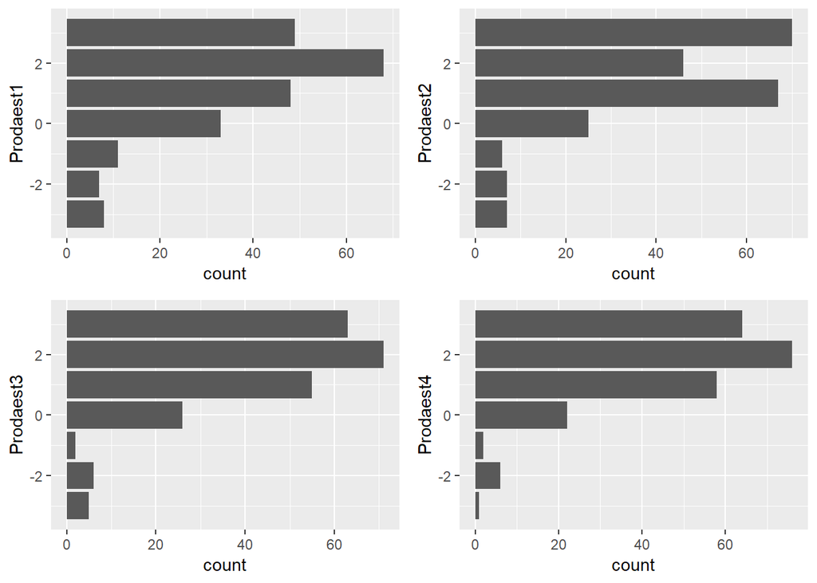

```r
# Use grid.arrange to show all the quantiry of variables showing the imapact of sales

grid.arrange(
  U_A %>%
    ggplot(aes(Prodaest1)) +
    geom_bar() +
    coord_flip(),
  U_A %>%
    ggplot(aes(Prodaest2)) +
    geom_bar() +
    coord_flip(),
  U_A %>%
    ggplot(aes(Prodaest3)) +
    geom_bar() +
    coord_flip(),
  U_A %>%
    ggplot(aes(Prodaest4)) +
    geom_bar() +
    coord_flip(),
  ncol=2)
```

#Comments - Materialistic values are also important to the female market - the female market seems to be both hedonistic and materialistic #Questions - Does the brand UA fit the theme of materialistic ?

## 6.1 Univariate graphical - quantitative

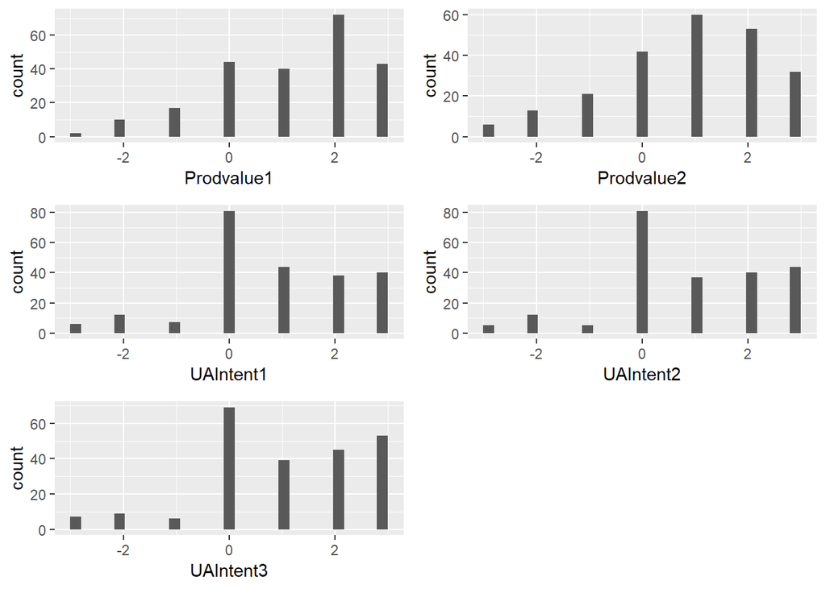

```r
grid.arrange(
  U_A %>%
    ggplot(aes(Prodvalue1)) +
      geom_histogram(),
  U_A %>%
    ggplot(aes(Prodvalue2)) +
      geom_histogram(),
  U_A %>%
    ggplot(aes(UAIntent1)) +
      geom_histogram(),
  U_A %>%
    ggplot(aes(UAIntent2)) +
      geom_histogram(),
  U_A %>%
    ggplot(aes(UAIntent3))+
      geom_histogram(),

  ncol = 2
)
```

# Comments - most of customer results are towards the yes side for all of the follow variables. - The most counts for UAIntent category is neutrual - This shows that people ’s intention of purchasing UA is mostly on the neutral side

## 6.2 Boxplot

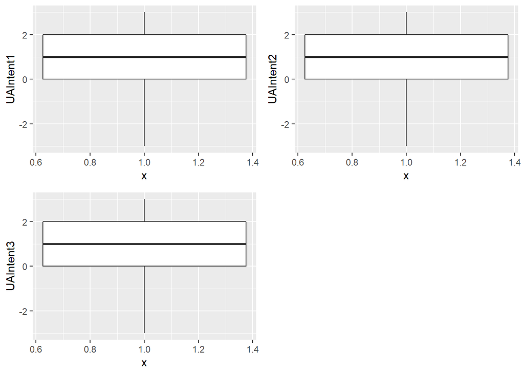

```r
# Set x = 1 to make a boxplot of a single continuous variable
  ## because the boxplot does not have a width associated with it so gives alignment
grid.arrange (
  ggplot(U_A, aes(x = 1, y = UAIntent1)) +
    geom_boxplot(),

  ggplot(U_A, aes(x = 1, y = UAIntent2)) +
    geom_boxplot(),

  ggplot(U_A, aes(x = 1, y = UAIntent3)) +
    geom_boxplot(),

    ncol = 2
)
```

#comments - the box plot shows that most of the female customers surveyed are welling to purchase the Under armour brand some time in the future. - The three box plot results are very similar

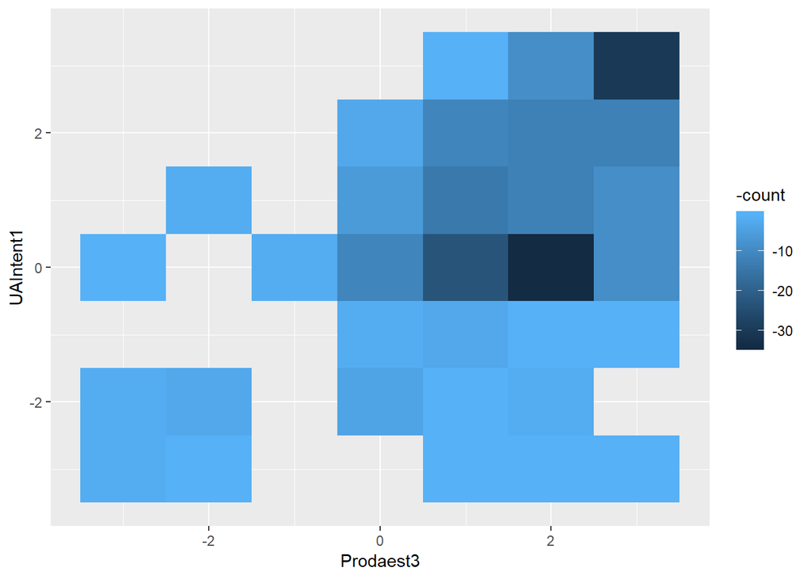

```r
U_A %>%
  group_by(Prodaest3, UAIntent1) %>%
  summarise(count = n()) %>%
  ggplot(aes(Prodaest3, UAIntent1)) +
  geom_tile(aes(fill = -count)) # Put "-" in front of "count" to reverse color order
```

# 7 Comments

- it seems like not every one filled up every parts of the survey
- most of the female consumers are more likely to purchase the product in the future if the sports appearl is good

## 7.1 Multi-variate graphical - quantitative

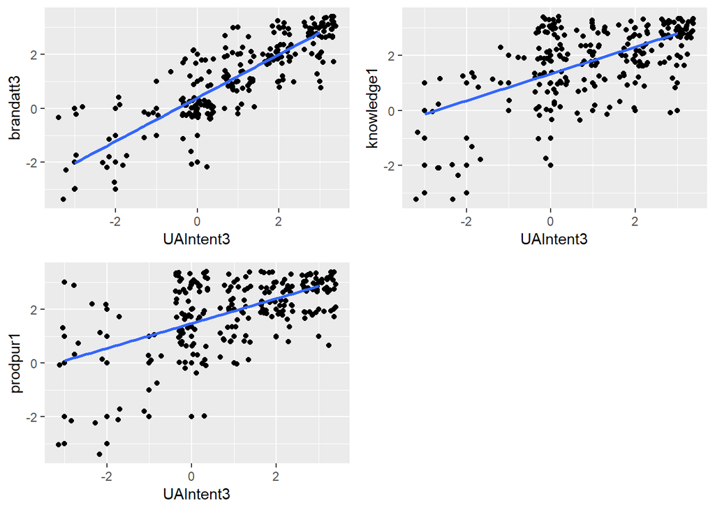

```r
# Code scatterplots using grid.arrange so can see all quantity variables of interest together
grid.arrange(
  U_A %>%
    ggplot(aes(UAIntent3, brandatt3)) +
    geom_point() +
    geom_jitter() +
    geom_smooth(method = "lm", se = FALSE),

  U_A %>%
    ggplot(aes(UAIntent3, knowledge1)) +
    geom_point() +
    geom_jitter() +
    geom_smooth(method = "lm", se = FALSE),

  U_A %>%
    ggplot(aes(UAIntent3, prodpur1)) +
    geom_point() +
    geom_jitter() +
    geom_smooth(method = "lm", se = FALSE),

  ncol = 2
)
```

#comments - the regression lines shows that as people knows more about the brand, the more likely they will be purchasing the product

- the regression line of second graph shows that as people know more about the product they are more likely to purchase the product
- the regression line of third graph shows intention to purchase performance apparel is positively correlated to intention of purchasing UA

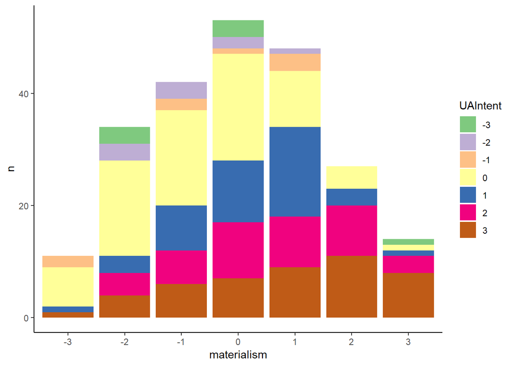

```r
U_A.Comb %>%
  group_by(materialism, UAIntent) %>% # subsets for each of these variables
  filter(UAIntent != "NaN") %>%
  summarize(n = n()) %>%
  ggplot(aes(x = materialism, y = n, fill = UAIntent)) +
    geom_bar(stat = 'identity') +
    theme_classic()+
    scale_fill_brewer(palette = "Accent")
```

# comments - This graphs shows that the majority of buyers who are likely to purchase UA are only alittle bit of materiailism. - UA satisfies majority of female consumers materialistic needs

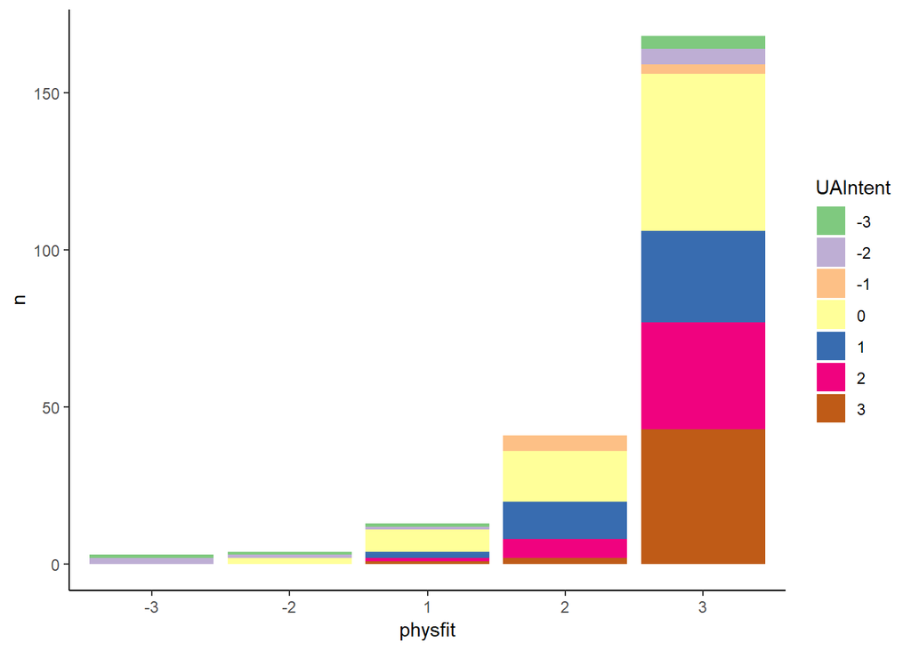

```r
U_A.Comb %>%
  group_by(physfit, UAIntent) %>% # subsets for each of these variables
  filter(UAIntent != "NaN") %>%
  summarize(n = n()) %>%
  ggplot(aes(x = physfit, y = n, fill = UAIntent)) +
    geom_bar(stat = 'identity') +
    theme_classic()+
    scale_fill_brewer(palette = "Accent")
```

#comments - people recongnize UA as more of a physical fit brand as majority of extreme physical fit consumers are more likely to purchase UA in the future.

```r
head(U_A.num)
```

```
##   brandatt1 brandatt2 brandatt3 Cause1 Cause2 Cause3 compan1 compan2
## 1         2         1         2      2      2      3       3       2
## 2         1         1         1      3      1      3       2       1
## 3         2         3         2      2      1      3       2       2
## 4         1         1         1      2      2      3       2       2
## 5         2         2         1     -2      1     -2       0       1
## 6         3         3         3      3      3      3       3       3
##   compan3 CSR1 CSR2 CSR3 environ1 environ2 environ3 knowledge1 knowledge2
## 1       3    3    0    0        3        3        3          1          2
## 2       3    2    2    0        1       NA        1          2          2
## 3       3    2    2    2        2        1        2          3          1
## 4       3    3    3    3        3        3        3          3          1
## 5       2    0   NA    2        3        2        2          0          2
## 6       3    3    3    3        3        3        3          3          3
##   knowledge3 materialism1 materialism2 materialism3 physfit1 physfit2
```

[output cut: 62 more lines]